# Clustering By Clique Paritioning: Clique Similarity Framework

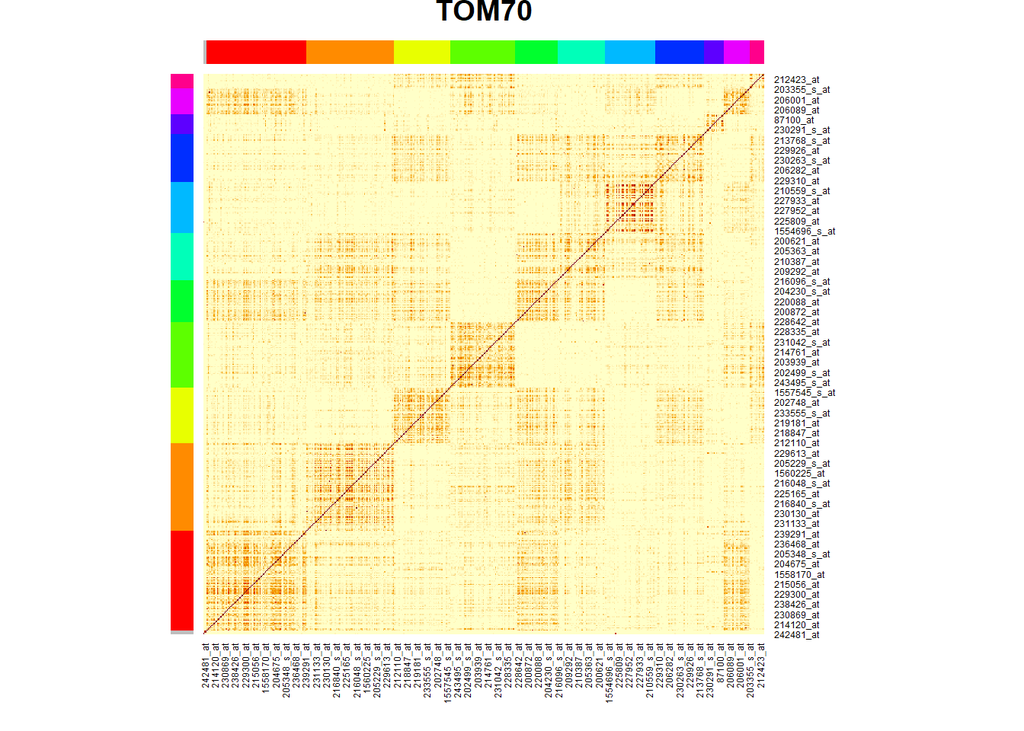

```r
heatmap_clusters(mat=base_S, labs = tom_mcs[[7]],main=paste0("TOM",mcs_values[[1]]))
```

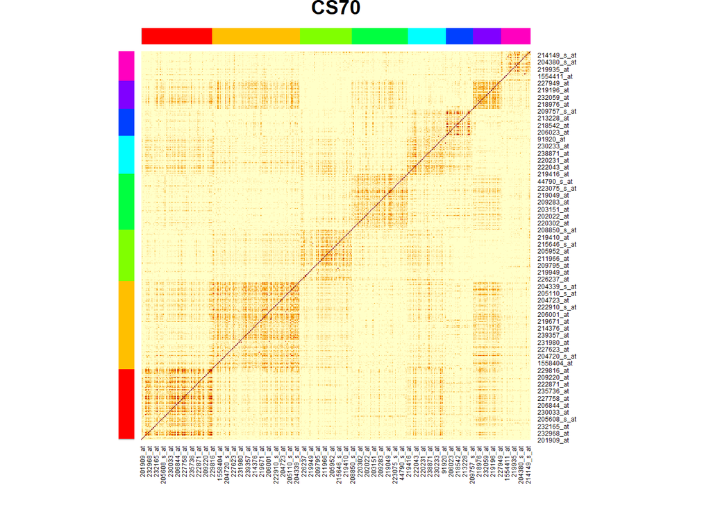

```r
heatmap_clusters(mat=base_S, labs = cs_mcs[[7]],main=paste0("CS",mcs_values[[1]]))
```

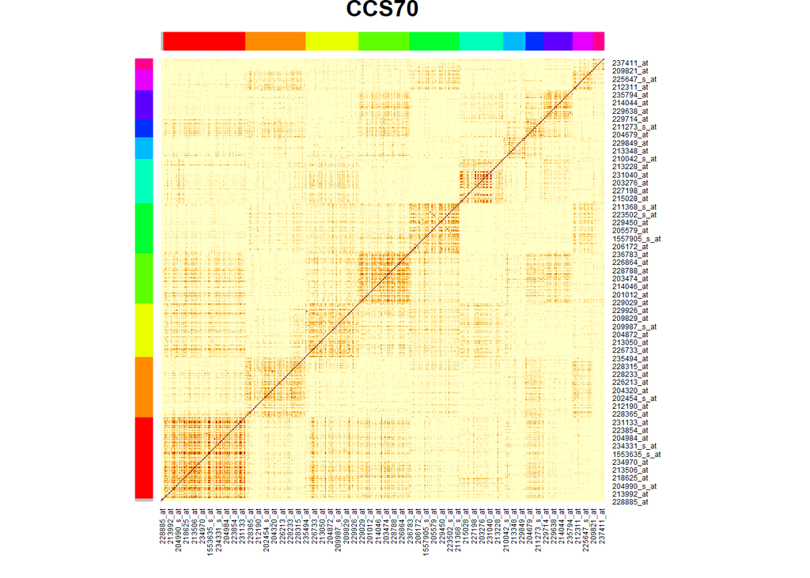

```r
heatmap_clusters(mat=base_S, labs = ccs_mcs[[7]],main=paste0("CCS",mcs_values[[1]]))
```

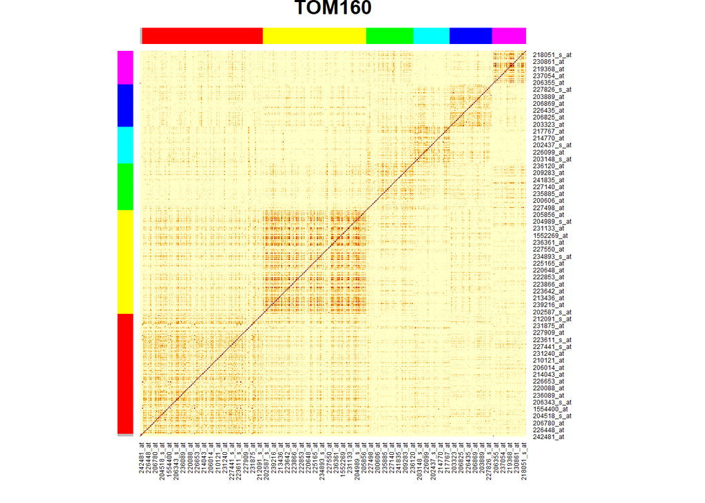

```r
heatmap_clusters(mat=base_S, labs = tom_mcs[[16]],main=paste0("TOM",mcs_values[[2]]))
```

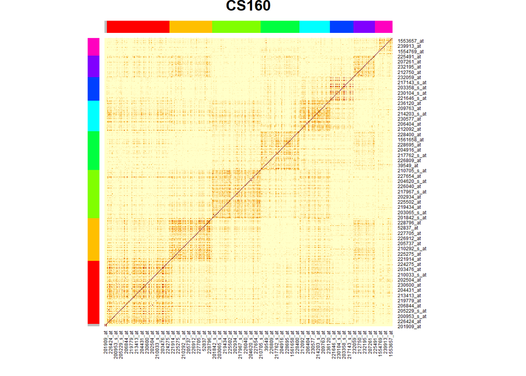

```r
heatmap_clusters(mat=base_S, labs = cs_mcs[[16]],main=paste0("CS",mcs_values[[2]]))
```

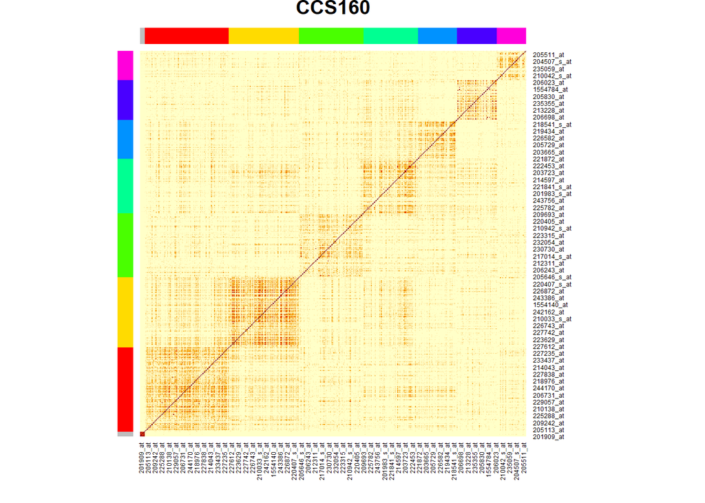

```r
heatmap_clusters(mat=base_S, labs = ccs_mcs[[16]],main=paste0("CCS",mcs_values[[2]]))
```

#### The final test

We computed DTC for two variants of the parameter and Affinity Propagation for all of the 3 similarity measures on the same set of resamples. DTC was manageable on the desktop computer - code below (took approx. 2.5 hours). Afterwards, AP was run on a HPC cluster concurrently for each repetition (check the `AP_*.R` scripts in the repo). As far as the concern with the RNG generation in parallel goes - seeds were set for each repetition. Only non-determinisitc aspect of AP is the addition of noise to the similarities, which is not expected to affect the clustering results much, so we neglected the possible correlation in between RNG streams.

```r
if (!file.exists("after_mcsXsimXgene.RData")){

mcsXsimXgene<- array(NA, dim = c(length(mcs_values), length(simXmcs),
                                 B/n_rep,ncol(X)
                                 ),
                     dimnames= list( mcs_values|> as.character(),
                                     names(simXmcs),

                                     seq_len(B/n_rep),
                                     colnames(X)
                                     )
                     )

mcsXsimXgene["70","TO",1,]= simXmcs$TO[[7]]
mcsXsimXgene["160","TO",1,]=simXmcs$TO[[16]]
mcsXsimXgene["70","CS",1,]= simXmcs$CS[[7]]
mcsXsimXgene["160","CS",1,]=simXmcs$CS[[16]]
mcsXsimXgene["70","CCS",1,]= simXmcs$CCS[[7]]
mcsXsimXgene["160","CCS",1,]=simXmcs$CCS[[16]]




for (r in 2:(B/n_rep)){
  for (m in seq_along(mcs_values)){
    mcs= mcs_values[[m]]
  CCSg<-matrix(0,nrow=ncol(X),ncol=ncol(X))
 # CCSh<-matrix(0,nrow=ncol(X),ncol=ncol(X))
  CS<- matrix(0, nrow=ncol(X), ncol=ncol(X))
  b_start<- 1 + ( r- 1)*n_rep
  message(b_start)
  start_t<- Sys.time()
 for  (b in c(b_start: (b_start+ (n_rep-1)  ))){
   message("############")
   absCor<- abs(corfast(X[ BS[[b]],]|>as.matrix() ))
   S_t<- absCor^2
   S_t[ S_t < t_[[b]] ] = 0
   csg<- cliqueSimilarity(Pg_[[b]], S_t)
   #csh<- cliqueSimilarity(Ph_[[b]], S_t)
   p_dtc<- DTC_groups(absCor^2, mcs = mcs)
   CS= CS + outer(p_dtc,p_dtc, function(x,y) as.numeric(x==y))
   message(Sys.time()-start_t)
   ecsg<- expand_CS_toNodes(csg, cl_mem=Pg_[[b]])
   #ecsh<- expand_CS_toNodes(csh, cl_mem=Pg_[[b]])
   #message(Sys.time()-start_t)
   CCSg<- CCSg + ecsg
   #CCSh<-CCSh + ecsh
   #message(Sys.time()-start_t)
   if (b==b_start) { TOM<- tom(absCor^2)
     mcsXsimXgene[ m, "TO", r,]= DTC_groups(TOM, mcs = mcs)
   }
 }
  CCSg<- CCSg/n_rep
  #CCSh<-CCSh/n_rep
  CS<- CS/n_rep
  #mcsXsimXgene[m,"CS",r,]= DTC_groups(sim=CS, mcs=mcs)
  mcsXsimXgene[m,"CCS",r,]=DTC_groups(sim=CCSg, mcs=mcs)
  message(Sys.time()-start_t)
  }
  }



save.image(file="after_mcsXsimXgene.RData")} else {
  load("after_mcsXsimXgene.RData")
}
```

##### DTC

```r
ARI_matrices<- array(NA, dim=c(2,3,B/n_rep,B/n_rep),
                     dimnames = list(c("70","160"),
                                     names(simXmcs),
                                     seq_len(B/n_rep),
                                     seq_len(B/n_rep)))
for (i_mcs in 1:2)
  for (i_sim in 1:3){
    ARI_matrices[i_mcs,i_sim,,]=ARI_mat(cl_list = as.data.frame(t(mcsXsimXgene[i_mcs,i_sim,,])))

  }
library(reshape2)
```

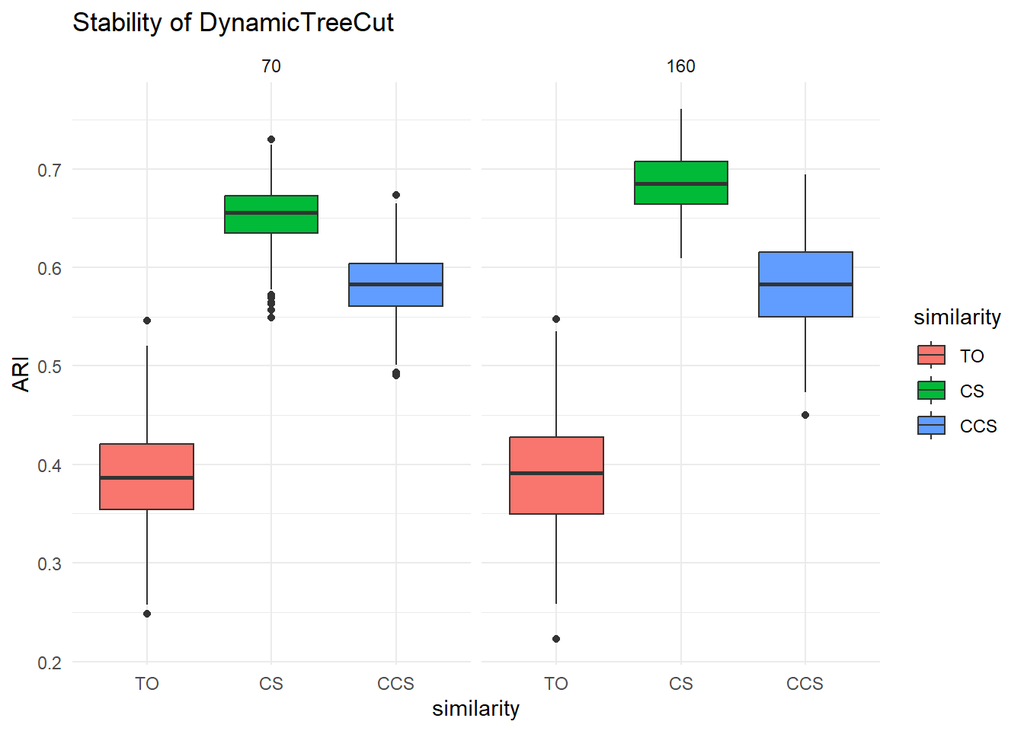

```r
ari_flat<- melt(ARI_matrices)
colnames(ari_flat)<- c("minClusterSize","similarity","i","j","ARI")
ari_flat<- ari_flat[ ari_flat$i<ari_flat$j,]
library(ggplot2)
#pdf("DTC_results.pdf",height=3,width=4)
ggplot(ari_flat, aes(x=similarity, y=ARI, fill=similarity))+geom_boxplot()+
  facet_wrap(minClusterSize~.) + theme_minimal()+
  ggtitle("Stability of DynamicTreeCut")
```

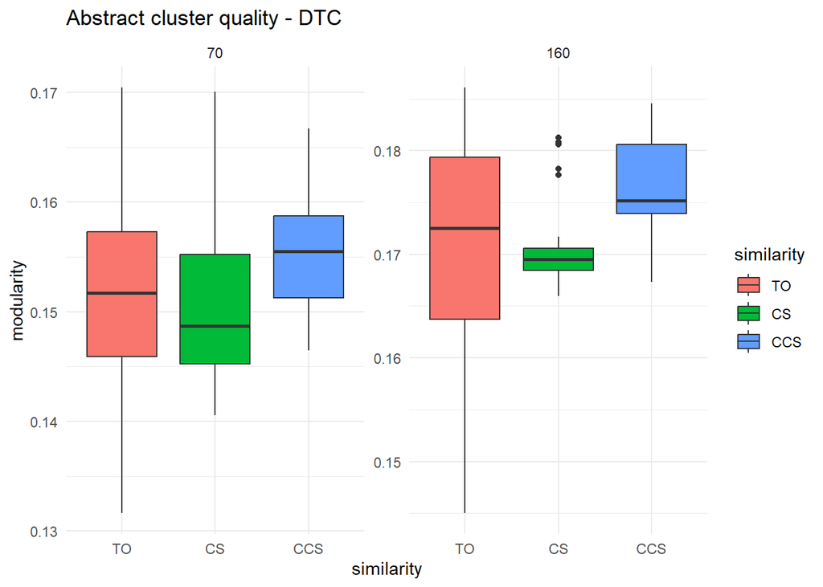

```r
if (!file.exists("performance_dtc.rds")){
performance_array<-array(NA, dim=c(2,3,B/n_rep),
                          dimnames=list(c("70","160"),
                                        names(simXmcs),
                                        seq_len(B/n_rep)))

library(igraph)
for (m in 1:2)
  for (sim in names(simXmcs))
      for (r in seq_len(B/n_rep)){
      performance_array[m,sim,r]= modularity_fromMatrix(base_S, mcsXsimXgene[m,sim,r,] )
      message(sprintf("m=%d;sim=%s,r=%d",m,sim,r))
      }
saveRDS(performance_array, "performance_dtc.rds")
} else {
 performance_array<- readRDS("performance_dtc.rds")
}
flat_perf<-melt(performance_array)
colnames(flat_perf)<-c("minClusterSize","similarity","rep","modularity")

ggplot(flat_perf, aes(x=similarity, y=modularity, fill=similarity))+ geom_boxplot()+
  facet_wrap(minClusterSize~., scales="free_y") +
  ggtitle("Abstract cluster quality - DTC") +
  theme_minimal()
```

```r
#dev.off()
```

##### AP

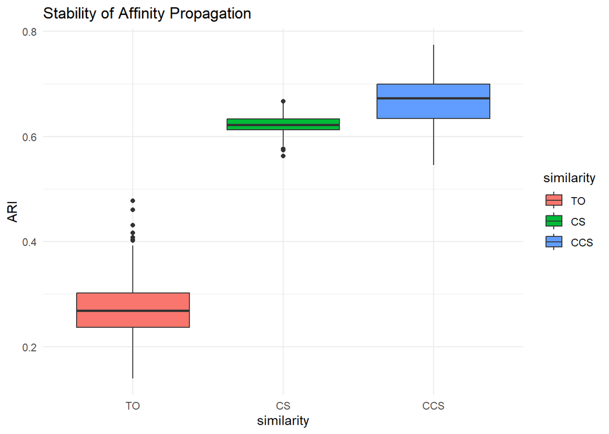

```r
#computed using AP_*.R scripts
load("AP_results_aggregated.RData")

#pdf("AP_results_fulldata.pdf", width=5, height=5)
AP_ARI_flat<-melt(AP_ARI_matrices)
colnames(AP_ARI_flat)<- c("similarity","i","j","ARI")
AP_ARI_flat<- AP_ARI_flat[ AP_ARI_flat$i< AP_ARI_flat$j, ]
ggplot(AP_ARI_flat, aes(x=similarity, y=ARI, fill=similarity))+geom_boxplot()+
  ggtitle("Stability of Affinity Propagation")+
  theme_minimal()
```

```r
AP_perf_flat<- melt(AP_performance_array)
head(AP_perf_flat)
```

```
##          Var1 Var2 Var3      value
## 1  modularity   TO    1 0.08840945
## 2 conductance   TO    1 0.18833172
## 3  modularity   CS    1 0.01440054
## 4 conductance   CS    1 0.02365350
## 5  modularity  CCS    1 0.07079683
## 6 conductance  CCS    1 0.04564585
```

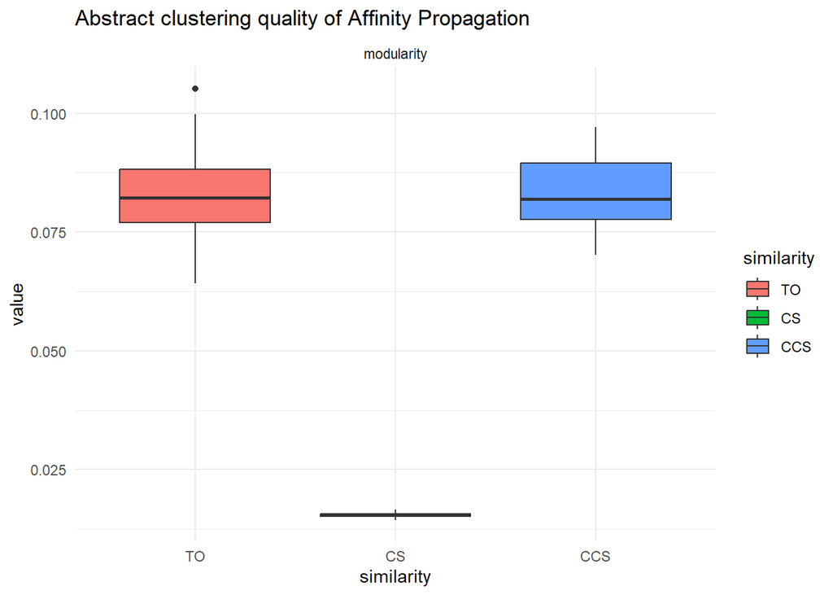

```r
colnames(AP_perf_flat)<- c("metric","similarity","r","value")
AP_perf_flat<- AP_perf_flat[ AP_perf_flat$metric=="modularity",]
ggplot(AP_perf_flat, aes(x=similarity, y=value, fill=similarity))+ geom_boxplot()+
  ggtitle("Abstract clustering quality of Affinity Propagation")+
  facet_wrap(metric~., scales = "free_y")+theme_minimal()
```

```r
#dev.off()
```

##### Module-trait association investigation

How well each gene grouping matches distinct tissue types?

One could argue that the perfect, biologically significant result has the 1-1 matching between each distinct module and each distinct tumor subtype, as far as strongest, statistically significant association is concerned.

For each repetition, we measure such “matching” by computing association of each type to each module by usage of $MI$-test (between binary indicator of a subtype and eigengene of each module).

We want to count how many times, the best fitting module for each type also chooses that type as its preference. One catch here is that we normalize the association strength type-wise. This does not change the preference of the type but changes the best fitting type for each module. Some of the types are easily discernible by majority of the modules, this normalization mitigates that.

Steps are as follows:

1. Compute association of each of the 5 subtypes $Y_i$ to each module eigengene $E_k$ by $MI$ test= $A_{ik}= MI(E_k,Y_i) \times [p.value_{ik}<0.05]$
2. Normalise: $\widehat{A_{ik}}= A_{ik}/\sum_l A_{il}$

Compute preferences:

$Y_{pref}(i) = \arg max_{k} \widehat{A_{ik}}$

$E_{pref}(k) = \arg max_{i} \widehat{A_{ik}}$

```r
# setting up the data structures, merging results from both algorithms to one array
AP_expanded<- array(AP_simXgene, dim=c(1, dim(AP_simXgene)),
                    dimnames = c(list( algorithm= "AP" ),
                                 dimnames(AP_simXgene) )
)

DTC_array<- mcsXsimXgene
dimnames(DTC_array)[[1]]<- c("DTC70", "DTC160")

algorithms= c("DTC70","DTC160","AP")
similarities<- c("TO","CS","CCS")

modules_array<- array(NA, dim=c(length(algorithms),
                                length(similarities),
                                B/n_rep,
                                ncol(X)),
                      dimnames = list(algorithms,similarities,
                                      seq_len(B/n_rep),
                                      colnames(X)))

modules_array[1:2, , , ] = DTC_array
modules_array[3, , , ] =  AP_expanded
```

```r
#setting up structures to hold the results of the association tests
#for each similarity and algorithm we can get a matrix of size
# n_types x n_modules, n_modules can vary across methods and repeats
unique(y_char)-> types

Y<- lapply(types, function(y) 1*(y_char==y)) |> as.data.frame()
colnames(Y)<- types

algorithmXsimXrepXtraitXmodule<- vector(mode="list", length=3)

names(algorithmXsimXrepXtraitXmodule)<- algorithms
for (al in algorithms)
  algorithmXsimXrepXtraitXmodule[[al]]= vector(mode="list",length=3)

for (al in algorithms)
  names(algorithmXsimXrepXtraitXmodule[[al]])<- similarities

for (al in algorithms)
  for (sim in similarities)
    algorithmXsimXrepXtraitXmodule[[c(al,sim)]]=vector(mode="list",
                                                       length=n_rep)

library(MDFS)

for (al in algorithms){
  for (sim in similarities)
    for (r in 1:n_rep)
    {
      P<-zeroOutSmall(modules_array[al, sim, r,],2)
      unique(P[P!=0])-> mods
        eigengenes<- lapply(mods, function(mod)
                                prcomp(X[, P==mod],scale.=TRUE,
                                       rank.=1)$x[,1]) |> as.data.frame()
        PV<-MI<- matrix(nrow=ncol(Y),
                    ncol=ncol(eigengenes))
        rownames(PV)<-rownames(MI)<-types
        for (type in types){
         MDFS(data = eigengenes, decision = Y[,type], divisions = 1, dimensions = 1,
              discretizations = 30, range=0.3, seed=124)-> mdfs
        MI[type,]=mdfs$statistic
        PV[type,]=mdfs$p.value
        }
        PV[,]= p.adjust(PV)
        MI [ PV >= 0.05 ] = 0
        MI<-MI/rowSums(MI)
       algorithmXsimXrepXtraitXmodule[[c(al,sim,r)]]=MI
    }
       message(sprintf(" %s & %s done",al,sim))
}
```

```r
# count the number of matches
n_type_matches<- array(NA, dim=c(3,3,n_rep),
                       dimnames = list(algorithms,
                                       similarities,
                                       1:n_rep))

for (al in algorithms)
  for (sim in similarities)
    for (r in 1:n_rep)
    {
      type_pref<-apply(algorithmXsimXrepXtraitXmodule[[c(al,sim,r)]],1, function(ROW)
        which.max(ROW))
      mod_pref<-apply(algorithmXsimXrepXtraitXmodule[[c(al,sim,r)]],2, function(COL)
        which.max(COL))
      type_matches=0
      for (i_t in seq_along(type_pref)){
        type_matches= type_matches+ 1*( mod_pref[[ type_pref[[i_t]] ]] == i_t )
      }
      n_type_matches[al,sim,r]=type_matches
    }
```

```r
# plot the results
melt(n_type_matches)->n_match_flat
head(n_match_flat)
```

```
##     Var1 Var2 Var3 value
## 1  DTC70   TO    1     4
## 2 DTC160   TO    1     3
## 3     AP   TO    1     3
## 4  DTC70   CS    1     5
## 5 DTC160   CS    1     5
## 6     AP   CS    1     5
```

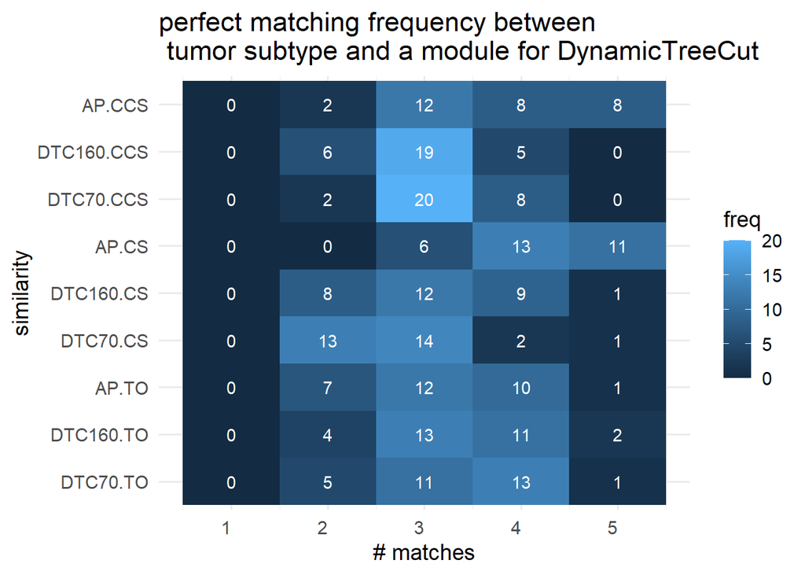

```r
colnames(n_match_flat)<-c("algorithm","similarity","repeat","n_matches")
n_match_flat$n_matches<- factor(n_match_flat$n_matches, levels=c(0:5))
n_match_flat$algorithmXsimilarity= interaction(n_match_flat$algorithm,
                                               n_match_flat$similarity)
table(n_match_flat$algorithmXsimilarity,
      n_match_flat$n_matches) |> melt()-> n_match_tabulation

colnames(n_match_tabulation)<- c("algorithmXsimilarity","n_matches","freq")
#pdf("tumor_module_matchingFreq.pdf", width=8,height=6)
ggplot(n_match_tabulation[(n_match_tabulation$n_matches!=0)#&
                         # grepl("DTC",n_match_tabulation$algorithmXsimilarity
                          #)
                          ,], aes(x=n_matches, y=algorithmXsimilarity,
                               fill=freq) ) + geom_tile() +
  labs(
    x = "# matches",
    y = "similarity",
    title = "perfect matching frequency between \n tumor subtype and a module for DynamicTreeCut"
  ) +
  theme_minimal(base_size = 14) +
  theme(
    axis.text.x = element_text(angle = 0, hjust = 1),
    strip.text = element_text(face = "bold")
  ) + geom_text(aes(label=freq),color="white") +
  theme(legend.postition= "none")
```

```r
#dev.off()
```

[output not shown]